# rbasic_20190909_385_fields

# Chapter 4: Programming Basics

We teach R because it greatly facilitates data analysis, the main topic of this book. By coding in R, we can efficiently perform exploratory data analysis, build data analysis pipelines and prepare data visualization to communicate results. However, R is not just a data analysis environment but a programming language. Advanced R programmers can develop complex packages and even improve R itself, but we do not cover advanced programming in this book. Nonetheless, in this section, we introduce three key programming concepts: conditional expressions, for-loops and functions. These are not just key building blocks for advanced programming, but are sometimes useful during data analysis. We also note that there are several functions that are widely used to program in R but that we will not cover in this book. These include *split, cut, do.call* and *Reduce*. These are worth learning if you plan to become an expert R programmer.

# 4.1 Conditional Expressions

Conditional expressions are one of the basic features of programming. They are used for what is called *flow control*. The most common conditional expression is the if-else statement. In R, we can actually perform quite a bit of data analysis without conditionals. However, they do come up occasionally, and you will need them once you start writing your own functions and packages.

Here is a very simple example showing the general structure of an if-else statement. The basic idea is to print the reciprocal of a unless a is 0:

```r
a <- 0

if(a!=0) {
  print(1/a)
}else{
  print("No reciprocal for 0.")
}
```

```
[1] "No reciprocal for 0."
```

Let’s look at one more example using the US murders data frame:

```r
library(dslabs)
data(murders)

murder_rate <- murders$total / murders$population*1000
```

```r
ind <- which.min(murder_rate)

if(murder_rate[ind] < 0.25){
  print(murders$state[ind])
}else{
  print("No state has a murder rate that low")
}
```

```
[1] "Vermont"
```

```r
if(murder_rate[ind] < 0.25){
  print(murders$state[ind])
} else{
  print("No state has a murder rate that low.")
}
```

```
[1] "Vermont"
```

A related function that is very useful is ifelse. This function takes three arguments: a logical and two possible answers. If the logical is **TRUE**, the value in the second argument is returned and if **FALSE**, the value in the third argument is returned. Here is an example:

```r
a <- 0
ifelse(a > 0, 1/a, NA)
```

```
[1] NA
```

The function is particularly useful because it works on vectors. It examines each entry of the logical vector and returns elements from the vector provided in the second argument, if the entry is **TRUE**, or elements from the vector provided in the third argument, if the entry is **FALSE**.

```r
a <- c(0,1,2,-4,5)
result <- ifelse(a > 0, 1/a, NA)
```

Here is an example of how this function can be readily used to replace all the missing values in a vector with zeros:

```r
data(na_example)
no_nas <- ifelse(is.na(na_example), 0, na_example)
sum(is.na(no_nas))
```

```
[1] 0
```

Two other useful functions are *any* and *all*. The any function takes a vector of logicals and returns **TRUE** if any of the entries is **TRUE**. The *all* function takes a vector of logicals and returns **TRUE** if all of the entries are **TRUE**. Here is an example:

```r
z <- c(TRUE, TRUE, FALSE)
any(z)
```

```
[1] TRUE
```

```r
all(z)
```

```
[1] FALSE
```

## 4.2 Defining Functions

As you become more experienced, you will find yourself needing to perform the same operations over and over. A simple example is computing averages. We can compute the average of a vector *x* using the *sum* and *length* functions: *sum(x)/length(x)*. Because we do this repeatedly, it is much more efficient to write a function that performs this operation. This particular operation is so common that someone already wrote the *mean* function and it is included in base R. However, you will encounter situations in which the function does not already exist, so R permits you to write your own. A simple version of a function that computes the average can be defined like this:

```r
avg <- function(x){
  s <- sum(x)
  n <- length(x)
  s/n
}
```

Now **avg** is a function that computes the mean:

```r
x <- 1:100
identical(mean(x), avg(x))
```

```
[1] TRUE
```

Notice that variables defined inside a function are not saved in the workspace. So while we use **s** and **n** when we call avg, the values are created and changed only during the call. Here is an illustrative example:

```r
s <- 3
avg (1:10)
```

```
[1] 5.5
```

```r
s
```

```
[1] 3
```

Note how **s** is still 3 after we call **avg**.

The functions you define can have multiple arguments as well as default values. For example, we can define a function that computes either the arithmetic or geometric average depending on a user defined variable like this:

```r
avg <- function(x, arithmetic = TRUE){
  n <- length(x)
  infelse(arithmetic, sum(x)/n, prod(x)^(1/n))
}
```

We will learn more about how to create functions through experience as we face more complex tasks.

## 4.3 Namespaces

So what does R do when we type *filter*? Does it use the **dplyr** function or the stats function? From our previous work we know it uses the **dplyr** one. But what if we want to use the stats version?

These function live in different *namespaces*. R will follow a certain order when searching for a function in these *namespaces*. You can see the order by typing:

```r
search()
```

```
 [1] ".GlobalEnv"        "package:dslabs"    "package:forcats"   "package:stringr"
 [5] "package:dplyr"     "package:purrr"     "package:readr"     "package:tidyr"
 [9] "package:tibble"    "package:ggplot2"   "package:tidyverse" "tools:rstudio"
[13] "package:stats"     "package:graphics"  "package:grDevices" "package:utils"
[17] "package:datasets"  "package:methods"   "Autoloads"         "package:base"
```

The first entry in this list is the global environment which includes all the objects you define.

So what if we want to use the stats *filter* instead of the **dplyr** *filter* but **dplyr** appears first in the search list? You can force the use of a specific name space by using double colons (::) like this:

```r
stats::filter
```

[output not shown]

[output cut: 12 more lines]

[output not shown]

If we want to be absolutely sure we use the **dplyr** filter we can use

```r
dplyr::filter
```

```
function (.data, ..., .preserve = FALSE)
{
    UseMethod("filter")
}
<bytecode: 0x7f9c5b93e0e8>
<environment: namespace:dplyr>
```

Also note that if we want to use a function in a package without loading the entire package, we can use the double colon as well.

For more on this more advanced topic we recommend the [R Packages book](http://r-pkgs.had.co.nz/namespace.html).

## 4.4 For-loops

The formula for the sum of the series 1+2+⋯+n is n(n+1)/2. What if we weren’t sure that was the right function? How could we check? Using what we learned about functions we can create one that computes the Sn:

```r
compute_s_n <- function(n){
  x <- 1:n
  sum(x)
}
```

Perhaps the simplest example of a for-loop is this useless piece of code:

```r
for(i in 1:15){
  print(i)
}
```

```
[1] 1
[1] 2
[1] 3
[1] 4
[1] 5
[1] 6
[1] 7
[1] 8
[1] 9
[1] 10
[1] 11
[1] 12
[1] 13
[1] 14
[1] 15
```

Here is the for-loop we would write for our Sn example:

```r
m <- 25
s_n <- vector(length = m) # create an empty vector
for(n in 1:m){
  s_n[n] <- compute_s_n(n)
}
```

In each iteration n=1, n=2, etc…, we compute Sn and store it in the *n*th entry of s_n.

Now we can create a plot to search for a pattern:

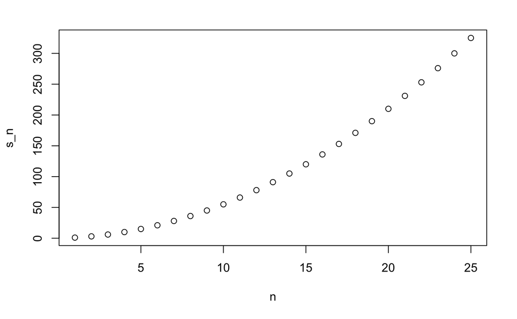

```r
n <- 1:m
plot(n, s_n)
```

If you noticed that it appears to be a quadratic, you are on the right track because the formula is n(n+1) / 2, which we can confirm with a table:

```r
head(data.frame(s_n = s_n, formula = n*(n+1) / 2))
```

|  | s_n | formula |
| --- | --- | --- |
| 1 | 1 | 1 |
| 2 | 3 | 3 |
| 3 | 6 | 6 |
| 4 | 10 | 10 |
| 5 | 15 | 15 |
| 6 | 21 | 21 |

We can also overlay the two results by using the function *lines* to draw a line over the previously plotted points:

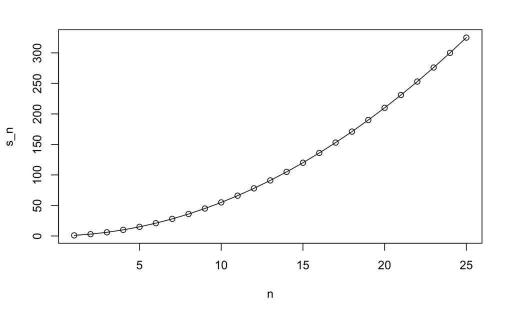

```r
plot(n, s_n)
lines(n, n*(n+1) / 2)
```

## 4.5 Vectorization and Functionals

Although for-loops are an important concept to understand, in R we rarely use them. As you learn more R, you will realize that *vectorization* is preferred over for-loops since it results in shorter and clearer code. We already saw examples in the Vector Arithmetic Section. A *vectorized* function is a function that will apply the same operation on each of the vectors.

```r
x <- 1:10
sqrt(x)
```

```
 [1] 1.000000 1.414214 1.732051 2.000000 2.236068 2.449490 2.645751 2.828427 3.000000
[10] 3.162278
```

```r
y <- 1:10
x*y
```

```
 [1]   1   4   9  16  25  36  49  64  81 100
```

To make this calculation, there is no need for for-loops. However, not all functions work this way. For instance, the function we just wrote, *compute_s_n*, does not work element-wise since it is expecting a scalar. This piece of code does not run the function on each entry of *n*:

```r
n <- 1:25
compute_s_n(n)
```

```
numerical expression has 25 elements: only the first used
```

```
[1] 1
```

*Functionals* are functions that help us apply the same function to each entry in a vector, matrix, data frame or list. Here we cover the functional that operates on numeric, logical and character vectors: **sapply**.

The function **sapply** permits us to perform element-wise operations on any function. Here is how it works:

```r
x <- 1:10
sapply(x, sqrt)
```

```
 [1] 1.000000 1.414214 1.732051 2.000000 2.236068 2.449490 2.645751 2.828427 3.000000
[10] 3.162278
```

Each element of *x* is passed on to the function *sqrt* and the result is returned. These results are concatenated. In this case, the result is a vector of the same length as the original *x*. This implies that the for-loop above can be written as follows:

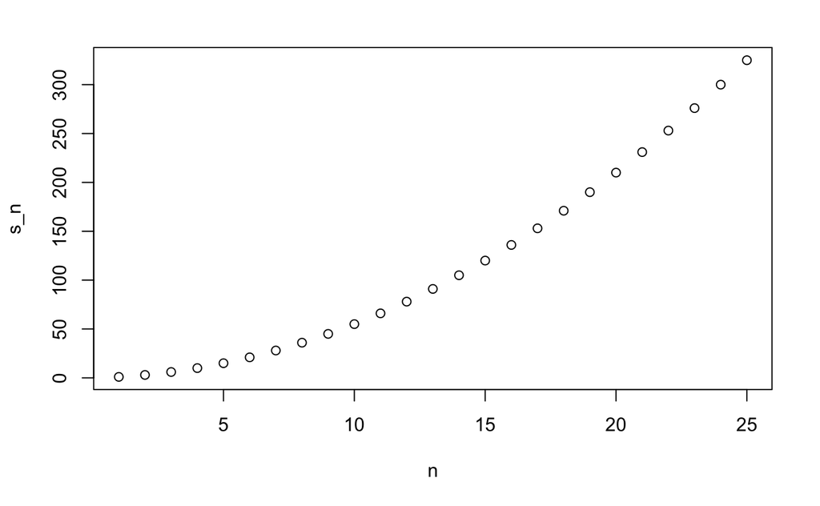

```r
n <- 1:25
s_n <- sapply(n, compute_s_n)
plot(n, s_n)
```

Other functionals are *apply, lapply, tapply, mapply, vapply*, and *replicate*. We moslty use *sapply, apply*, and *replicate* in this book, but we recommend familiarizing yourselves with the others as they can be very useful.

## 4.6 Exercises

1. What will this conditional expression return?

```r
x <- c(1,2,-3,4)

if(all(x>0)){
  print("All Positives")
}else{
  print("Not all positives")
}
```

```
[1] "Not all positives"
```

2. Which of the following expressions is always FALSE when at least one entry of a logical vector x is TRUE?

A. all(x)

C. any(!x)

D. all(!x)

3. The function *nchar* tells you how many characters long a character vector is.

Write a line of code that assigns to the object *new_names* the state abbreviation when the state name is longer than 8 characters

```r
x <- state.abb
if(all(x>8)){
  print(new_names)
}
```

[output not shown]

4. Create a function sum_n that for any given value, say n, computes the sum of the integers from 1 to n (inclusive). Use the function to determine the sum of integers from 1 to 5,000.

```r
sum_n <- sum(1:5000)
sum_n
```

```
[1] 12502500
```

5. Create a function altman_plot that takes two arguments, x and y, and plots the difference against the sum.

```r
altman_plot <- (x == y)
```

```
longer object length is not a multiple of shorter object length
```

```r
n <- 10
n2 <- 10*2
compute_s_n <-(1^2+2^2+3^2+n2)
compute_s_n
```

```
[1] 34
```

8. Define an empty numerical vector s_n of size 25 using s_n <- vector(“numeric”, 25) and store in the results of S1,S2,…S25 using a for-loop.

```r
s_n <- vector("numeric", 25)
m <- 25
s_n <- vector(length = m) # create an empty vector
for(n in 1:m)
```

```
Error: Incomplete expression: for(n in 1:m)
```

9. Repeat exercise 8, but this time use sapply.

```r
?sapply
sapply(x, 25, simplify=TRUE, USE.NAMES=TRUE)
```

```
Error in match.fun(FUN) : '25' is not a function, character or symbol
```

10. Repeat exercise 8, but this time use map_dbl.

```r
??map_dbl
```

11.Plot Sn versus n. Use points defined by n=1,…,25.

```r
plot(n, Sn)
```

```
Error in xy.coords(x, y, xlabel, ylabel, log) : object 'Sn' not found
```

12. Confirm that the formula for this sum is Sn=n(n+1)(2n+1)/6

```r
Sn=n(n+1)(2n+1)/6
```